# Predicting Flight Delays at the Pittsburgh Airport

# 5. Comparison to 2006 Data

Cleaning the 2006 Data

```r
PIT_2006_raw <- read_excel("all_PIT_2006.xlsx")
#View(PIT_2006_Raw)
PIT_2006_1 <- select(PIT_2006_raw, -c(Year, Quarter, AirlineID, UniqueCarrier,FlightDate, Flights, FlightNum, TailNum, ActualElapsedTime, ArrDelSys15, ArrDelSys30, AirTime, ArrTimeBlk, DepDelSys15, DepDelSys30, DepTimeBlk, OriginState, OriginStateFips, OriginWac, DestState, DestStateFips, DestStateName, DestWac, TaxiIn, TaxiOut, WheelsOff, WheelsOn, CancellationCode, CarrierDelay, WeatherDelay, NASDelay,SecurityDelay,LateAircraftDelay))

#Convert to factors
PIT_2006_2 <- PIT_2006_1

PIT_2006_2$Month <- as.factor(PIT_2006_2$Month)
levels(PIT_2006_2$Month) <- c("Jan", "Feb", "Mar", "Apr", "May", "June", "July", "Aug", "Sep", "Oct", "Nov", "Dec")

PIT_2006_2$DayOfWeek <- as.factor(PIT_2006_2$DayOfWeek)
levels(PIT_2006_2$DayOfWeek) <- c("Mon", "Tues", "Wed", "Thur", "Fri", "Sat", "Sun")

PIT_2006_2$Carrier <- as.factor(PIT_2006_2$Carrier)
levels(PIT_2006_2$Carrier) <- c("JetBlue", "Continental", "Delta", "Atlantic", "Frontier", "Envoy", "Northwest", "PSA", "SkyWest", "AirBridge", "United", "US Airways", "Southwest", "ExpressJet", "Mesa")

PIT_2006_2$DayofMonth <- as.factor(PIT_2006_2$DayofMonth)
PIT_2006_2$Carrier <- as.factor(PIT_2006_2$Carrier)
PIT_2006_2$Origin <- as.factor(PIT_2006_2$Origin)
PIT_2006_2$OriginCityName <- as.factor(PIT_2006_2$OriginCityName)
PIT_2006_2$Dest <- as.factor(PIT_2006_2$Dest)
PIT_2006_2$DestCityName <- as.factor(PIT_2006_2$DestCityName)
PIT_2006_2$Diverted <- as.factor(PIT_2006_2$Diverted)
PIT_2006_2$DistanceGroup <- as.factor(PIT_2006_2$DistanceGroup)

#Create Adjusted Arrival and Departure Times (Earlier than 5:00am)

PIT_2006_2 <- mutate(PIT_2006_2, AdjArrTime = ifelse(ArrTime %in% 0:500, ArrTime+2400,ArrTime)) #ifelse(CrsDepTime %in% 2000:2400 & ArrTime %in%500:1600, ArrTime+2400, ArrTime)))

PIT_2006_2 <- mutate(PIT_2006_2, AdjDepTime = ifelse(DepTime %in% 0:500, DepTime+2400,DepTime))
#ifelse(CrsArrTime %in%2000:2400 & DepTime %in%500:1600, DepTime+2400, ArrTime)))

#Create Arrival and Depature Time Factors
PIT_2006_2$ArrTimeGroup[PIT_2006_2$ArrTime >=500 & PIT_2006_2$ArrTime <900] <- "Early Morning"
PIT_2006_2$ArrTimeGroup[PIT_2006_2$ArrTime >=900 & PIT_2006_2$ArrTime <1300] <- "Morning"
PIT_2006_2$ArrTimeGroup[PIT_2006_2$ArrTime >=1300 & PIT_2006_2$ArrTime <1700] <- "Afternoon"
PIT_2006_2$ArrTimeGroup[PIT_2006_2$ArrTime >=1700 & PIT_2006_2$ArrTime <2100] <- "Evening"
PIT_2006_2$ArrTimeGroup[PIT_2006_2$ArrTime >=2100 & PIT_2006_2$ArrTime <2500] <- "Night"
PIT_2006_2$ArrTimeGroup[PIT_2006_2$ArrTime >=00 & PIT_2006_2$ArrTime <100] <- "Night"
PIT_2006_2$ArrTimeGroup[PIT_2006_2$ArrTime >=100 & PIT_2006_2$ArrTime <500] <- "Late Night"

PIT_2006_2$DepTimeGroup[PIT_2006_2$DepTime >=500 & PIT_2006_2$DepTime <900] <- "Early Morning"
PIT_2006_2$DepTimeGroup[PIT_2006_2$DepTime >=900 & PIT_2006_2$DepTime <1300] <- "Morning"
PIT_2006_2$DepTimeGroup[PIT_2006_2$DepTime >=1300 & PIT_2006_2$DepTime <1700] <- "Afternoon"
PIT_2006_2$DepTimeGroup[PIT_2006_2$DepTime >=1700 & PIT_2006_2$DepTime <2100] <- "Evening"
PIT_2006_2$DepTimeGroup[PIT_2006_2$DepTime >=2100 & PIT_2006_2$DepTime <2500] <- "Night"
PIT_2006_2$DepTimeGroup[PIT_2006_2$DepTime >=00 & PIT_2006_2$DepTime <100] <- "Night"
PIT_2006_2$DepTimeGroup[PIT_2006_2$DepTime >=100 & PIT_2006_2$DepTime <500] <- "Late Night"

PIT_2006_2$ArrTimeGroup <- as.factor(PIT_2006_2$ArrTimeGroup)
PIT_2006_2$DepTimeGroup <- as.factor(PIT_2006_2$DepTimeGroup)

PIT_2006_2 <- mutate(PIT_2006_2,
                     ArrTimeGroup = recode_factor(ArrTimeGroup,
                              `1` = "Early Morning",
                              `2` = "Morning",
                              `3` = "Afternoon",
                              `4` = "Evening",
                              `5` = "Night",
                              `6` = "Late Night",),
                     DepTimeGroup = recode_factor(DepTimeGroup,
                              `1` = "Early Morning",
                              `2` = "Morning",
                              `3` = "Afternoon",
                              `4` = "Evening",
                              `5` = "Night",
                              `6` = "Late Night"
                                                  ))

PIT_2006_3 <- PIT_2006_2[!is.na(PIT_2006_2$ArrDelay), ]

#After removing NAs for outcome variable, cancellation and divertion records are also removed. Hence we remove those columns also fron analysis

PIT_2019_3 <- select(PIT_2006_3,-c(Cancelled, Diverted))
#summary(PIT_2019_3)


PIT_2006_ArrivePit <- PIT_2006_3[ which(PIT_2006_3$DestCityName =='Pittsburgh'),]
#summary(PIT_2019_ArrivePit)

PIT_2006_ArrivePit.df <- as.data.frame(PIT_2006_ArrivePit)
#summary(PIT_2019_ArrivePit.df)

PIT_2006_DepartPit <- PIT_2006_3[ which(PIT_2006_3$OriginCityName =='Pittsburgh'), ]
#summary(PIT_2019_DepartPit)

PIT_2006_DepartPit.df <- as.data.frame(PIT_2006_DepartPit)
#summary(PIT_2019_DepartPit.df)
```

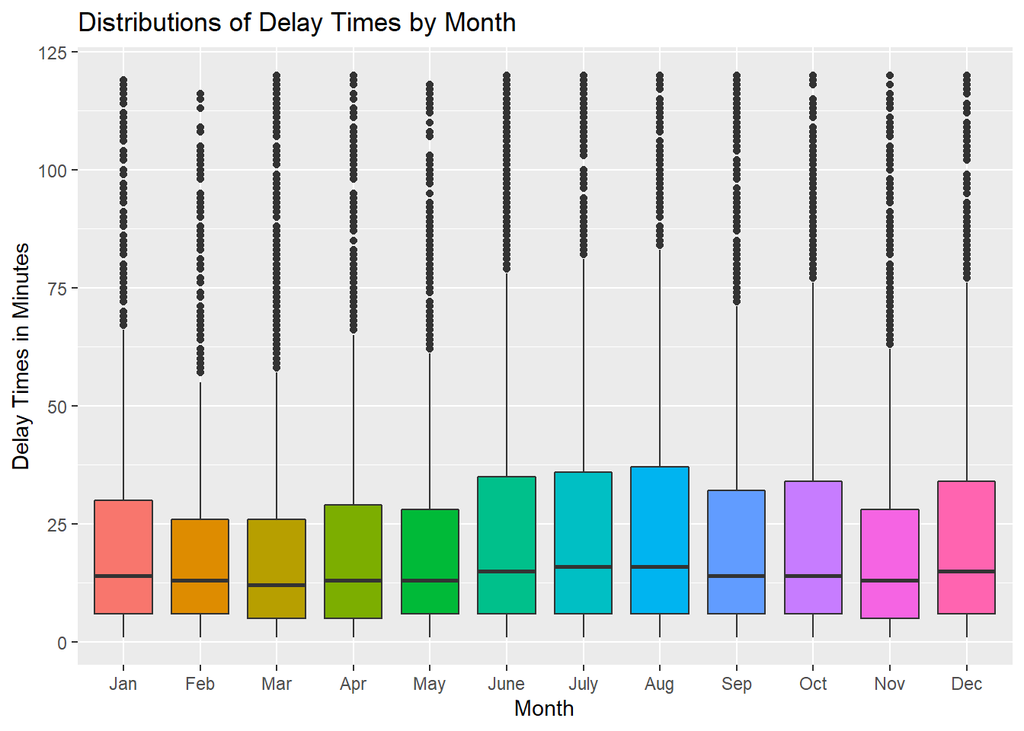

```r
greater602 <- subset(PIT_2006_ArrivePit.df, ArrDelay > 0 & ArrDelay <= 120)

#Arrival Delay by Month
ggplot(greater602, aes(x=Month, y=ArrDelay, fill=Month)) + geom_boxplot() + labs(title="Distributions of Delay Times by Month", x="Month", y="Delay Times in Minutes", fill= "Month")+ theme(legend.position="none")
```

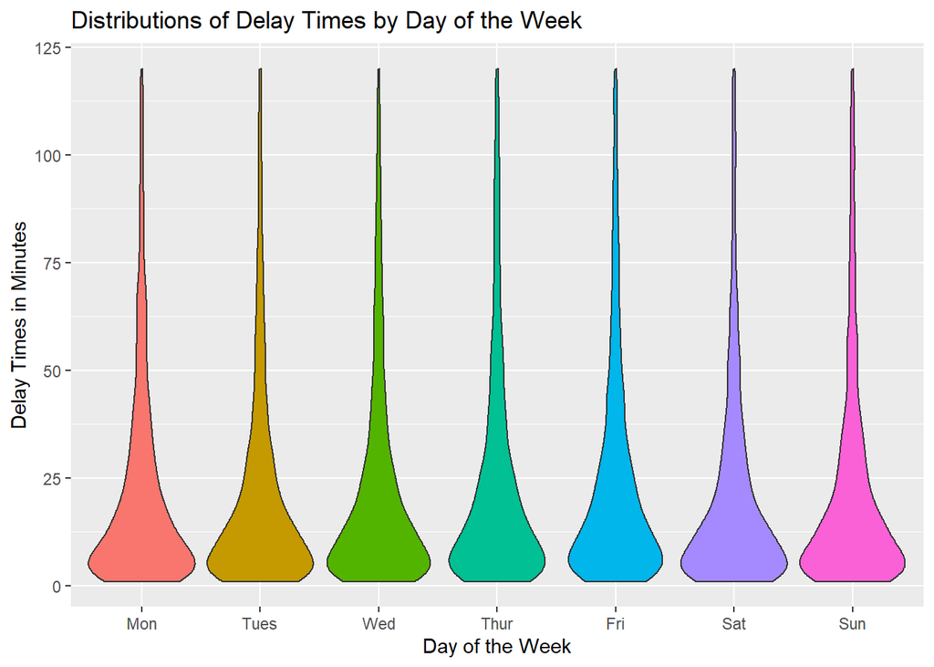

```r
#Arrival Delay by Day of Week
ggplot(greater602, aes(x=DayOfWeek, y=ArrDelay, fill=DayOfWeek)) + geom_violin() + labs(title="Distributions of Delay Times by Day of the Week", x="Day of the Week", y="Delay Times in Minutes", fill= "Day") + theme(legend.position="none")
```

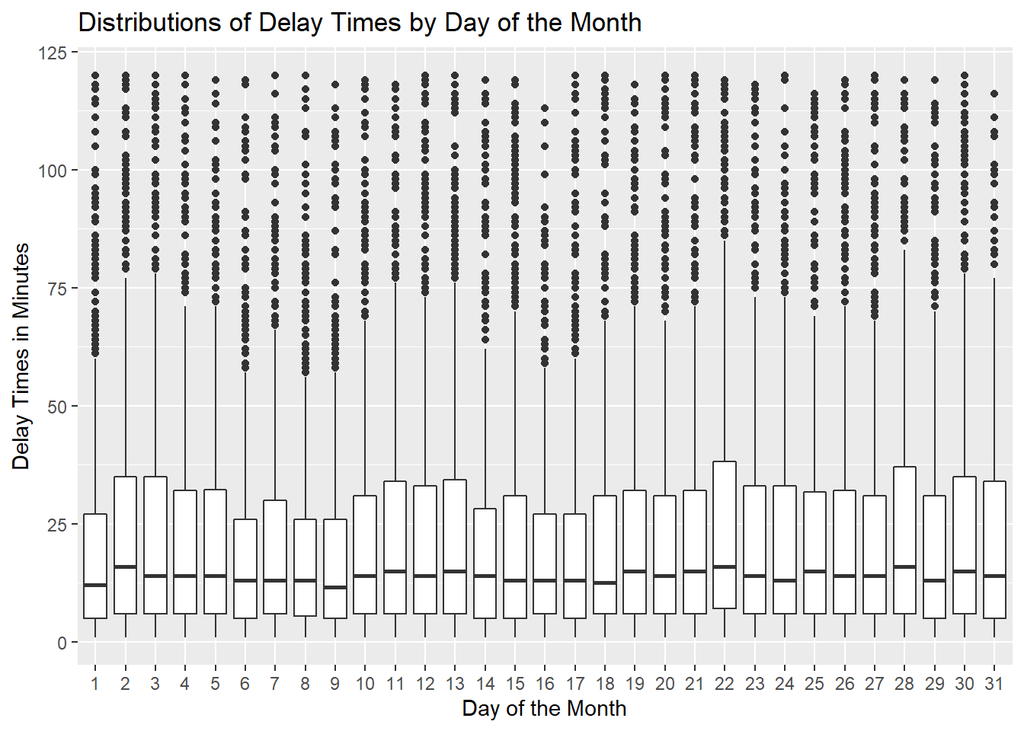

```r
#Arrival Delay by Day of Month
ggplot(greater602, aes(x=DayofMonth, y=ArrDelay)) + geom_boxplot() + labs(title="Distributions of Delay Times by Day of the Month", x="Day of the Month", y="Delay Times in Minutes")
```

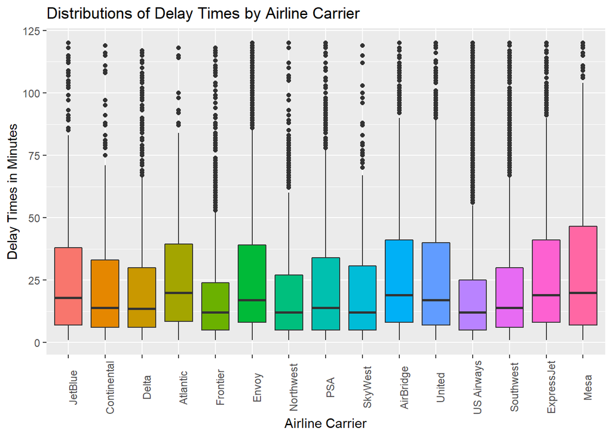

```r
#Arrival Delay by Carrier

ggplot(greater602, aes(x=Carrier, y=ArrDelay, fill=Carrier)) + geom_boxplot() + labs(title="Distributions of Delay Times by Airline Carrier", x="Airline Carrier", y="Delay Times in Minutes", fill= "Airline Carrier") + theme(legend.position="none", axis.text.x=element_text(angle=90))
```

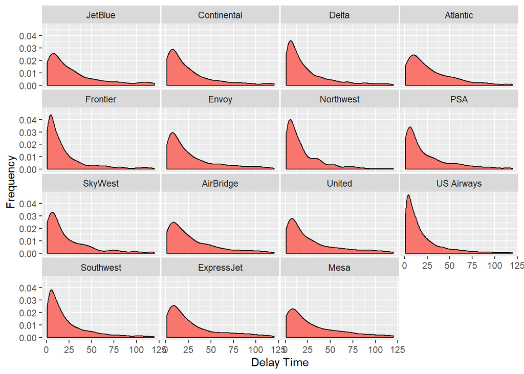

```r
car3 <- subset(PIT_2006_ArrivePit.df , ArrDelay>0 & ArrDelay<=120)
ggplot(car3, aes(x=ArrDelay, fill="Steelblue")) + geom_density(binwidth=15) + facet_wrap(~Carrier) + theme(legend.position="none", panel.spacing=unit(0.1, "lines")) + labs(x="Delay Time", y="Frequency")
```

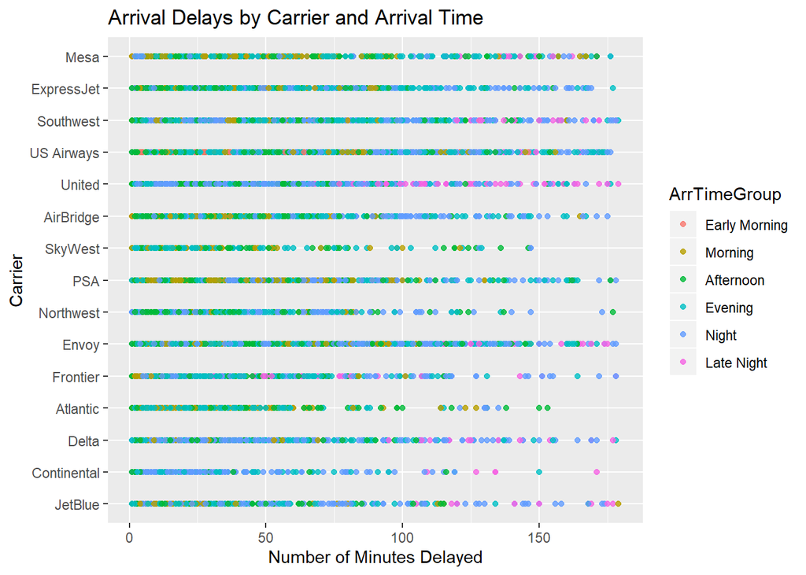

```r
less120a1 <- subset(PIT_2006_ArrivePit.df, ArrDelay > 0 & ArrDelay < 180)
less120d1 <- subset(PIT_2006_DepartPit.df, DepDelay > 0 & DepDelay < 180)

ggplot(data=less120a1, aes(x=ArrDelay, y=Carrier, color=ArrTimeGroup)) + geom_point(alpha=0.8) + labs(x="Number of Minutes Delayed", title="Arrival Delays by Carrier and Arrival Time", fill="Scheduled Arrival Time")
```

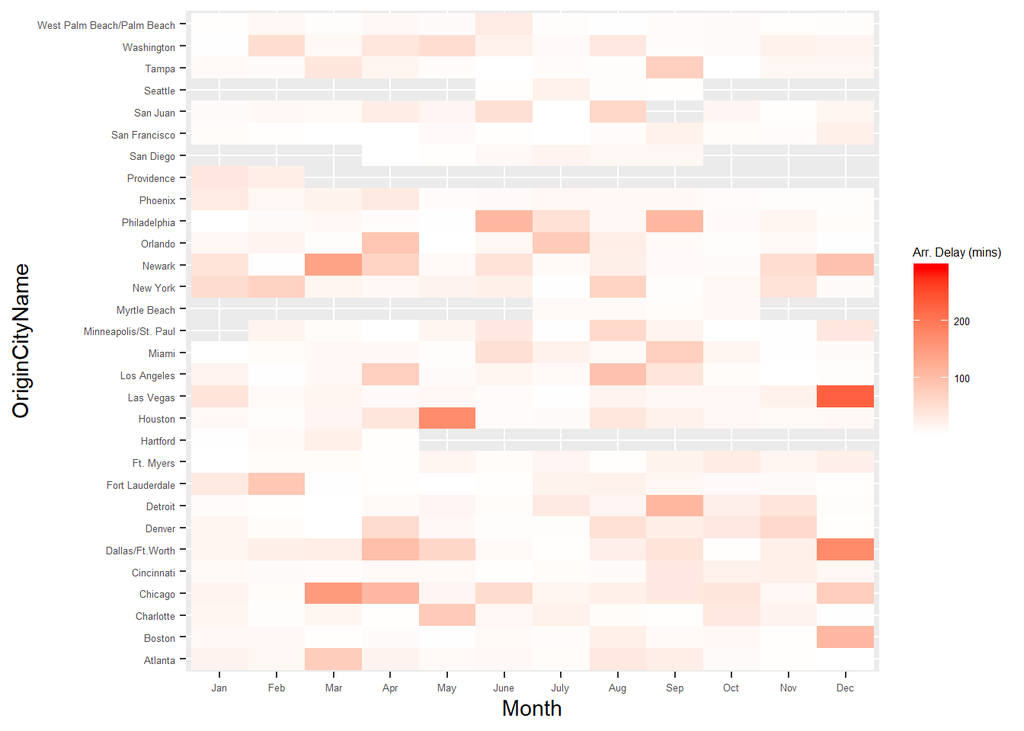

```r
arr12 <- subset(PIT_2006_ArrivePit.df, ArrDelay > 0 & ArrDelay <300 )

ggplot(arr12, aes(x=Month, y=OriginCityName, fill=ArrDelay)) + geom_tile() + scale_fill_gradient(low="white", high="red") +labs(fill="Arr. Delay (mins)") + theme(legend.title=element_text(size=6), legend.text = element_text(size=5), axis.text.x=element_text(size=5), axis.text.y=element_text(size=5))
```

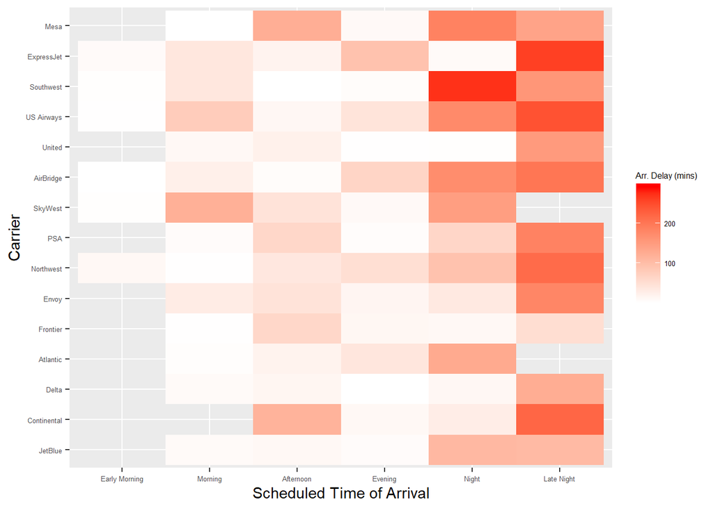

```r
ggplot(arr12, aes(x=ArrTimeGroup, y=Carrier, fill=ArrDelay)) + geom_tile() + scale_fill_gradient(low="white", high="red") +labs(x="Scheduled Time of Arrival", fill= "Arr. Delay (mins)") + theme(legend.title=element_text(size=6), legend.text = element_text(size=5), axis.text.x=element_text(size=5), axis.text.y=element_text(size=5))
```

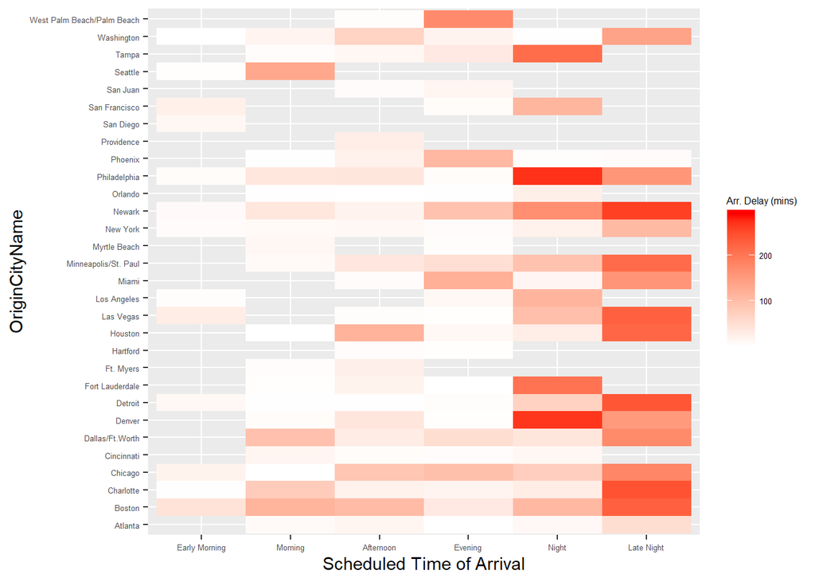

```r
ggplot(arr12, aes(x=ArrTimeGroup, y=OriginCityName, fill=ArrDelay)) + geom_tile() + scale_fill_gradient(low="white", high="red") +labs(x="Scheduled Time of Arrival", fill= "Arr. Delay (mins)") + theme(legend.title=element_text(size=6), legend.text = element_text(size=5), axis.text.x=element_text(size=5), axis.text.y=element_text(size=5))
```

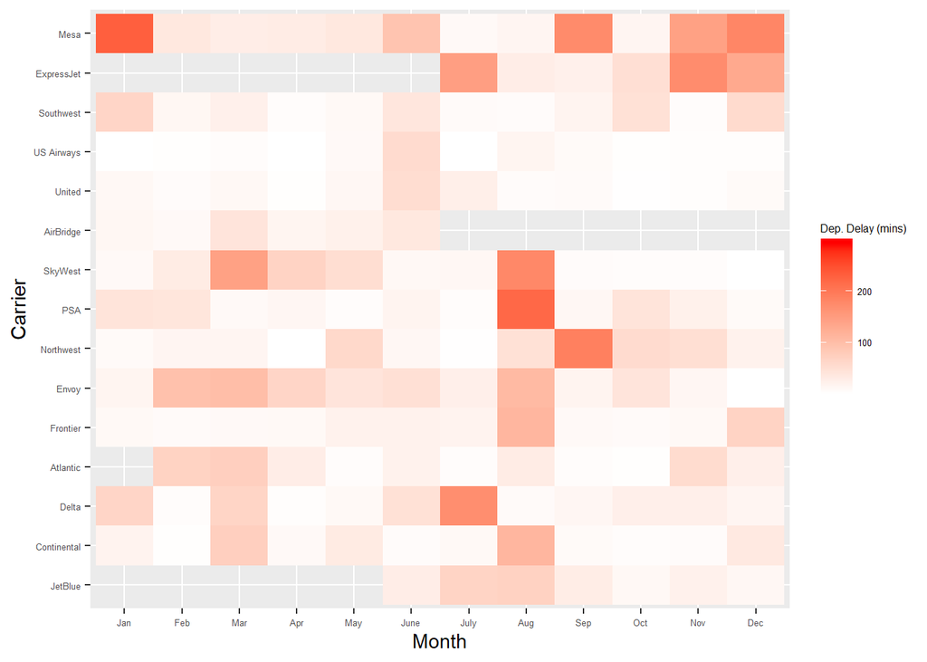

```r
dep12 <- subset(PIT_2006_DepartPit.df, DepDelay > 0 & DepDelay <300 )
ggplot(dep12, aes(x=Month, y=Carrier, fill=DepDelay)) + geom_tile() + scale_fill_gradient(low="white", high="red") +labs(fill="Dep. Delay (mins)") + theme(legend.title=element_text(size=6), legend.text = element_text(size=5), axis.text.x=element_text(size=5), axis.text.y=element_text(size=5))
```

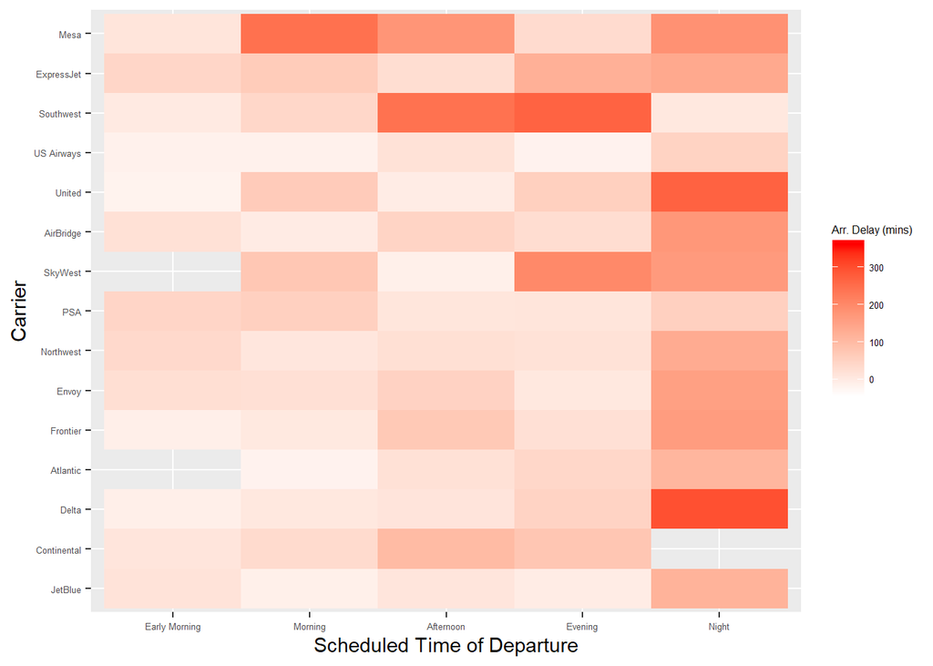

```r
ggplot(dep12, aes(x=DepTimeGroup, y=Carrier, fill=ArrDelay)) + geom_tile() + scale_fill_gradient(low="white", high="red") +labs(x="Scheduled Time of Departure",fill= "Arr. Delay (mins)") + theme(legend.title=element_text(size=6), legend.text = element_text(size=5), axis.text.x=element_text(size=5), axis.text.y=element_text(size=5))
```

**Comparison:**

In 2006, there was one fewer airline carrier in the Pittsburgh Airport, and over 5,800 fewer flights (which is equivalent to roughly 16 fewer flights per day). It is possible, therefore, that increased air traffic into and out of the Pittsburgh airport could create longer delays in 2019 than in 2006.

When comparing means, this is, in fact, what we observe. The average arrival delay in 2019 was 41.7 minutes, whereas in 2006 it was 31.6 minutes. The average departure delay in 2019 was 42.3 minutes, whereas in 2006 it was 31.3 minutes.

```r
tbl1 <- PIT_2019_2 %>% group_by(Carrier) %>%dplyr::summarize(Freq=n())
tbl1$Total <- sum(tbl1$Freq)
tbl1$Percentage_2019 <- round(((tbl1$Freq/tbl1$Total)*100),1)

tbl2 <- PIT_2006_3 %>% group_by(Carrier) %>%dplyr::summarize(Freq=n())
tbl2$Total <- sum(tbl2$Freq)
tbl2$Percentage_2006 <- round(((tbl2$Freq/tbl2$Total)*100),1)

tbl1<- tbl1[c("Carrier", "Percentage_2019")]
tbl2<- tbl2[c("Carrier", "Percentage_2006")]

tbl3 <- merge(x=tbl1, y=tbl2, by = "Carrier", all=TRUE)
tbl3[is.na(tbl3)] <- 0
tbl3
```

```
##        Carrier Percentage_2019 Percentage_2006
## 1     Endeavor             7.8             0.0
## 2     American            13.5             0.0
## 3       Alaska             0.7             0.0
## 4      JetBlue             3.9             2.3
## 5        Delta             7.7             4.5
## 6   ExpressJet             0.2             3.8
## 7     Frontier             0.3             4.1
## 8    Allegiant             2.3             0.0
## 9     Hawaiian             5.4             0.0
## 10       Envoy             4.1             9.8
## 11      Spirit             4.6             0.0
## 12         PSA             3.3             6.1
## 13     SkyWest             5.7             1.7
## 14      United            19.9             4.8
## 15   Southwest             3.0            15.0
## 16        Mesa            17.5             3.8
## 17 Continental             0.0             1.4
## 18    Atlantic             0.0             1.3
## 19   Northwest             0.0             3.7
## 20   AirBridge             0.0             3.6
## 21  US Airways             0.0            34.0
```

**Interpretation:**

In the table above, we can also see how the percentage of flights accounted for by each airline has changed since 2006. Some airlines have emerged that were not present in 2006 (either because they are newly formed businesses, they bought and rebranded existing businesses, or they simply began to operate in the Pittsburgh Airport). Endeavor, American, Alaska, Allegiant, Hawaiian and Spirit all represent airlines that were not present in 2006 in Pittsburgh, while Continental, Atlantic, Northwest, AirBridge, and US Airways all represent airlines that have left Pittsburgh (as a result of going out of business, being bought and taken over by another company, or simply moving operations out of Pittsburgh). Overall, there is net 1 more airline operating in Pittsburgh in 2019 as compared to 2006 (16 airlines compared to 15). More airlines and more flights could lead to more competition over runway time, terminal space, gates, etc, which could explain part of the reason the average delay time has increased.

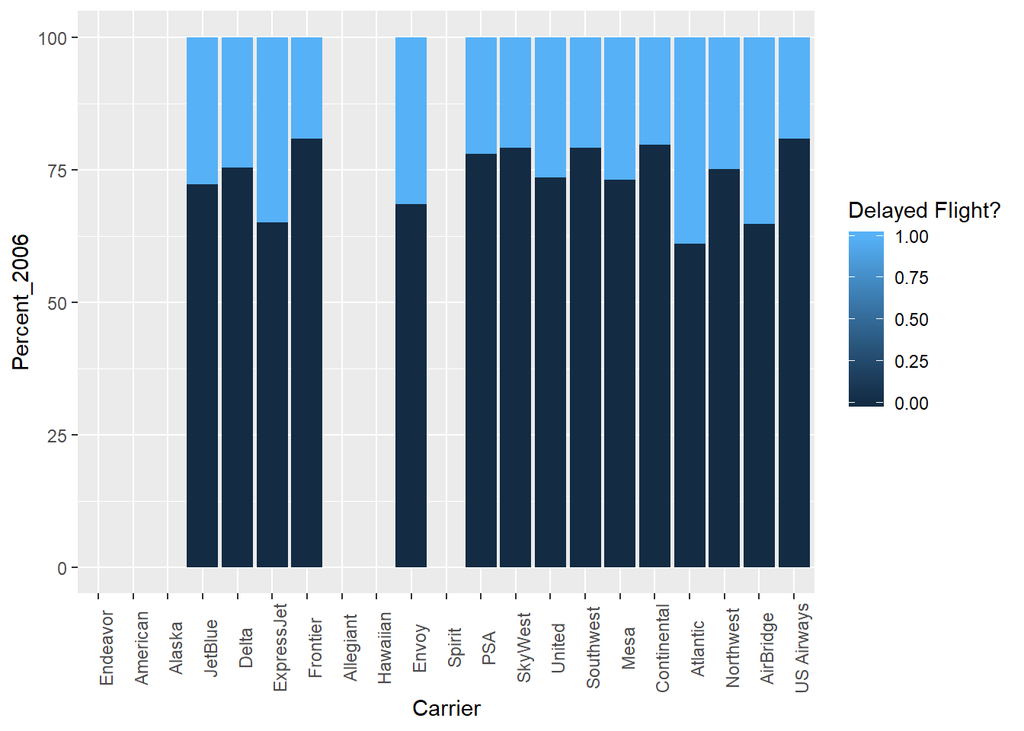

```r
PIT_Summary_2009 <- PIT_2019_2[!is.na(PIT_2019_2$ArrDel15), ]
tbla <- PIT_Summary_2009 %>% group_by(Carrier,ArrDel15) %>%dplyr::summarize(Freq=n())
tbla <- group_by(tbla, Carrier) %>% mutate(Percent_2019 = round(Freq/sum(Freq)*100,1))

PIT_Summary_2006 <- PIT_2006_3[!is.na(PIT_2006_3$ArrDel15), ]
tblb <- PIT_Summary_2006 %>% group_by(Carrier,ArrDel15) %>%dplyr::summarize(Freq=n())
tblb <- group_by(tblb, Carrier) %>% mutate(Percent_2006 = round(Freq/sum(Freq)*100,1))

tbla<- tbla[c("Carrier", "ArrDel15", "Percent_2019")]
tblb<- tblb[c("Carrier", "ArrDel15", "Percent_2006")]

tblc <- merge(x=tbla, y=tblb, by = c("Carrier", "ArrDel15"), all=TRUE)
tblc[is.na(tblc)] <- 0
#tblc

ggplot(tblc, aes(x= Carrier, y=Percent_2006, fill=ArrDel15)) + geom_bar(stat="identity") + theme(axis.text.x=element_text(angle=90)) + labs(fill="Delayed Flight?")
```

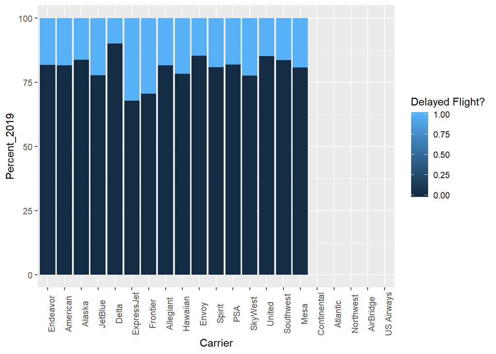

```r
ggplot(tblc, aes(x= Carrier, y=Percent_2019, fill=ArrDel15)) + geom_bar(stat="identity") + theme(axis.text.x=element_text(angle=90)) + labs(fill="Delayed Flight?")
```

**Interpretation:**

The light blue color in each graph above represents the percentage of flights that were delayed by 15 minutes or more. By comparing 2006 and 2019 percentages, we see that the percentage of flights that are delayed has actually improved (reduced) over this time period (the light blue area is smaller in 2019 than in 2006). Most individual carriers actually made improvements on this measure, with the exception of Frontier and SkyWest, which actually worsened. So, if the percentage of flights delayed is actually improving but the overall average length of delay is worsening, this means that the flights that are getting delayed must be experiencing longer delays than they were in 2006.

# 6. Findings

In this section we will make sure we clearly restate our findings.

### Question 1: Which of the features available in the PIT airport dataset are useful for predicting flight delays?

**Answer:** We have found that while there are some features that are highly predictive of arrival delays, these features are not useful in a practical sense. For example, using Departure Delay alone, we can account for about 95% of the variation in Arrival Delay. Additionally, adding Weather Delay and Carrier Delay to a model will improve this prediction even further. However, in a practical sense, these features are not useful because they are not values that are known well in advance of a flight. These are values that are typically determined only a few hours before a flight arrives. When looking at other features that are known well in advance of a flight (Destination and Origin Cities, Month, Day of the Week, Flight Distance, Scheduled Departure and Arrival Times), we find that many of these features (or certain categories within categorical features) may be highly significant in our models but do not yield much predictive power on their own. We found, time and again, that while there were highly significant correlations, the coefficient estimates for these predictors were typically very small and were thus unable to account for much of the variation in the outcome.

Predictors that were highly significant but have small coefficient estimates included: + Adjusted Arrival Time + Some (but not all) of the airline carriers (Delta and PSA Airlines are significant and ExpressJet is nearly significant) + Some of the cities are significant (Austin, Charleston, Charolette) + Over half of the months(March, April, June, July, September, October, November) + Some of the days of the week (Tuesday, Friday and Saturday) + Days of the month (26 of them are significant)

We believe there are two primary reasons we are unable to accurately model and predict this data. First, the data is not normally distributed (non-Gaussian). The distribution of delays is very highly skewed to the right, because about 80% of the flights have no delays whatsoever, while the remaining 20% is stretched over a very long tail. Even log transformations of this data hardly make an impact on normalizing the distribution because of this. Moving forward, we propose that analysts consider filtering the data to look at certain segments of the distribution at a time and try to develop predictive models from these filtered subsets. However, this will introduce much greater bias to the models so we have, for the most part, refrained from doing that here.

Additionally, we believe that the dataset lacks sufficient numeric features and relies heavily on categorical features, which have hindered our ability to fit more extensive models, like regression trees, on the data.

Additionally, many of the features in the dataset are highly correlated, which can render them not useful for predictive modeling. For example, our outcome variable (ArrDelayNew) is just a sum of 5 other variables (CarrierDelay, WeatherDelay, NasDelay, SecurityDelay and LateAircraftDelay). These variables, when used together, would perfectly predict ArrDelayNew, but are not useful practically. An interesting result of this is that we were not able to do cross-vaidation using all of these features because RStudio throws an error that says the model is already perfectly fit and that its nonsense to perform cross-validation.

### Question 2: Can the PIT airport data be used to produced a flight delay warning system?

**Answer:** While some of this data could be useful in developing a warning system, our results show that this data *alone* would not be able to accomplish the task of accurately predicting which flights will be delayed and by how much. It is true that we can develop an excellent prediction using some of the features in this dataset. For example, by incorporating Departure Delay into a model that predicts Arrival Delay, we can achieve an R-squared of about 0.95, meaning our model can account for 95% of the variance in the outcome (Arrival Delay). Additionally, by adding other features like Weather Delay or Carrier Delay, we can reach aout 0.99. But is such a system useful? We think not. The reason is because feature like arrival delay, weather delay, and carrier delay are not predictors whose values are known weeks or months in advance when customers are looking to purchase airfare. These are features that are determined typically hours before the arrival itself is delayed. So what features are fixed long in advance? Destination and origin cities, month, day of the week, flight distance, scheduled departure and arrival times, and airline carrier. If someone could reduce their chances of a delay flight by booking an early flight rather than a late one, they may want to know that. If they could book a Tuesday flight instead of a Wednesday flight, they might want to know that as well. Our results show that some of these features might be *somewhat* predictive, but they largely aren’t.

One way that we can try to develop a warning system from this data is by looking for other features in external datasets that are highly correlated with our feature. Take for example, WeatherDelay. If we could find variables that highly correlate to WeatherDelay (like humidity, temperature, precipitation, windspeed, atmospheric pressure, extreme weather), then we would likely be able to better predict delay times in advance.

### Question 3: What has changed at PIT airport since 2006 when it comes to flight delays?

Many of these comparisons have already been reported earlier in this report. We will simply restate some of the findings here.

1. Average delay time has increased by about 10-11 minutes for both arrivals to and departures from Pittsburgh.
2. There are more flights coming into and out of Pittsburgh (and more airlines operating in Pittsburgh) in 2019 than in 2006.
3. On average, airlines have actually reduced the number of flights delayed from 2006 to 2019, but average delay time is still longer for the flights that are delayed.
4. Many other trends that we noticed in the 2019 exploratory data analysis hold true for 2006 as well. For example:
   - Flight delays continue to be highly right-skewed distributions for both 2019 and 2006.
   - Carriers still tend to have much longer delays for flights that leave later in the day, in both 2019 and 2006.
   - Certain combinations of categorical variables (Carrier, Month, Destination and Origin city) continue to produce “hotspots” for delay times, though it is difficult to account for these interactions between categorical variables in our models.

# 7. Conclusion

Summarizing the exploration to build a predictive model for flight delays in Pittsburgh airport, we started with identifying the arrival delay as the outcome variable of interest and carried out our exploratory data analysis (EDA). We found some variables like departure delay to explain the arrival delay very well. And some delays like Security delay and weather delay contributed to the departure delay. But these are highly correlated with the arrival delay and wont be useful in prediction. Some other variables for which data will be available in advance like date of travel, flight carrier and arrival/ departure times has less variation among them and created doubts on how well the prediction model will be.

As expected, the multiple linear regression model with identified variables could predict only around 10% of the variation in the delay. With the non-linearity and skewed data as seen from diagnostic plots, regression was not the best model to forecast. The limitation in handling interaction effects by regression model also showed that a better model like regression trees can explain better.

The large number of categorical variables and the very few and insignificant continuous variable, made the prediction task little difficult. The regression trees could not be used due to limitation in number of factor levels that can be computed. Random forest package was used to build bagging and random forest model and we hoped the interaction to be taken care of. The model performed 4 times better than regression in explaining the changes in outcome. At the same time, we realized how other variables like weather, precipitation, wind speed, holidays, etc could explain the model better and give improved prediction. Even though models like random forest are not good at interpretation and makes it a black box for the common man, in this problem, where multiple factors influence the delay, tree-based models perform well. With more relevant variables, we can build a more robust model to predict flight delays.